# Taboo: Linguistic analysis

# Load data

## Taboo data

```r
# setwd("/Users/seantrott/Dropbox/UCSD/Research/Ambiguity/Taboo/Experiment1/analysis/reports")
df = read.csv("../../data/processed/aligned_results_public.csv")
nrow(df)
```

```
## [1] 20521
```

```r
table(df$session)
```

```
##
##    1    4    5    6    7    8    9   11   12   13   14   16   17   18   19   20
## 1281 1377 1090 1285 1302 1036 1431 1235 1109 1273  988  398 1391 1217 1201 2088
##   21
##  819
```

```r
length(unique(df$session))
```

```
## [1] 17
```

## Lexical statistics

```r
## Concreteness norms
df_concreteness = read_csv("../../data/lexical_statistics/brysbaert_norms.csv")
df_concreteness$word = df_concreteness$Word
## SUBTLEX frequency data
df_subtlex = read_csv("../../data/lexical_statistics/SUBTLEXusfrequencyabove1.csv")
df_subtlex$word = df_subtlex$Word
## AoA norms
df_aoa = read_csv("../../data/lexical_statistics/AoA_ratings_Kuperman_et_al_BRM.csv")
df_aoa$AoA = df_aoa$Rating.Mean
df_aoa$word = tolower(df_aoa$Word)
```

## Remove non-native speakers

```r
df = df %>%
  filter(Native_Speaker == "Yes")
nrow(df)
```

```
## [1] 19449
```

```r
length(unique(df$ppt_id))
```

```
## [1] 65
```

## Merge Taboo data with lexical statistics

### Merge with target concept

We then merge that data with the Taboo data to get `AoA`, `Frequency`, and `Concreteness` information about the target concept.

```r
df$word = tolower(df$card)
nrow(df)
```

```
## [1] 19449
```

```r
df_merged = df %>%
  inner_join(df_concreteness, by = "word") %>%
  inner_join(df_subtlex, by = "word") %>%
  inner_join(df_aoa, by = "word")
nrow(df_merged)
```

```
## [1] 17219
```

```r
### Now remove critical NA observations for these columns
df_merged = df_merged %>%
  drop_na(Conc.M) %>%
  drop_na(Lg10WF) %>%
  drop_na(AoA)
nrow(df_merged)
```

```
## [1] 17219
```

```r
### Also restrict POS to Noun, Verb, and Adjective
df_merged = df_merged %>%
  filter(Dom_Pos %in% c("Noun", "Verb", "Adjective"))
nrow(df_merged)
```

```
## [1] 17107
```

```r
table(df_merged$Dom_Pos)
```

```
##
## Adjective      Noun      Verb
##      1118     13666      2323
```

# Descriptive statistics

## Correlations between lexical statistics

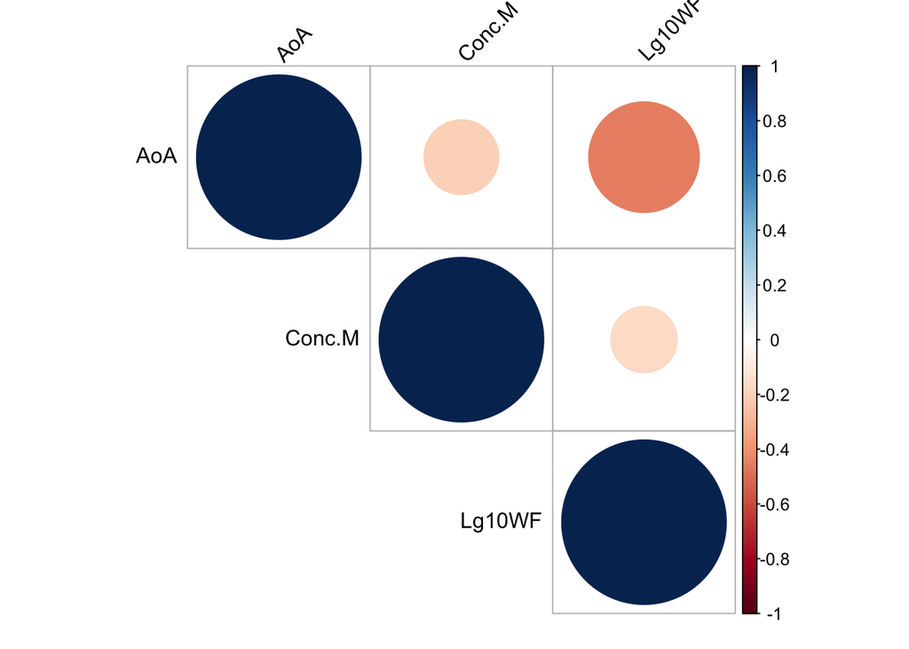

```r
df_select_variables = df_merged %>%
  dplyr::select(Conc.M, Lg10WF, AoA)

cors = cor(df_select_variables, method='pearson')

corrplot(cors, type = "upper", order = "hclust",
         tl.col = "black", tl.srt = 45)
```

## Noun Phrases

Here, we create a subset of the data for expressions that *can conceivably* vary in length.

```r
table(df_merged$RE_type)
```

```
##
## full NP   Other PRP 1st PRP 2nd PRP 3rd Unknown
##    4701    2826    1215    3269    4102     994
```

```r
df_just_nps = df_merged %>%
  filter(RE_type =="full NP")

df_just_nps %>%
  summarise(mean_length = mean(length),
            median_length = median(length),
            sd_length = sd(length))
```

```
##   mean_length median_length sd_length
## 1     2.27675             2 0.5955417
```

```r
nrow(df_just_nps)
```

```
## [1] 4701
```

What are the most common determiners / modifiers used for noun phrases that could vary in length?

```r
df_determiners = df_just_nps %>%
  group_by(det) %>%
  summarise(count = n(),
            prop = n() / nrow(df_just_nps))

head(df_determiners[order(-df_determiners$prop), ], 10)
```

```
## # A tibble: 10 × 3
##    det     count   prop
##    <fct>   <int>  <dbl>
##  1 a        1687 0.359
##  2 the      1326 0.282
##  3 your      365 0.0776
##  4 this      169 0.0359
##  5 an        146 0.0311
##  6 another   134 0.0285
##  7 my        100 0.0213
##  8 that       91 0.0194
##  9 no         58 0.0123
## 10 their      54 0.0115
```

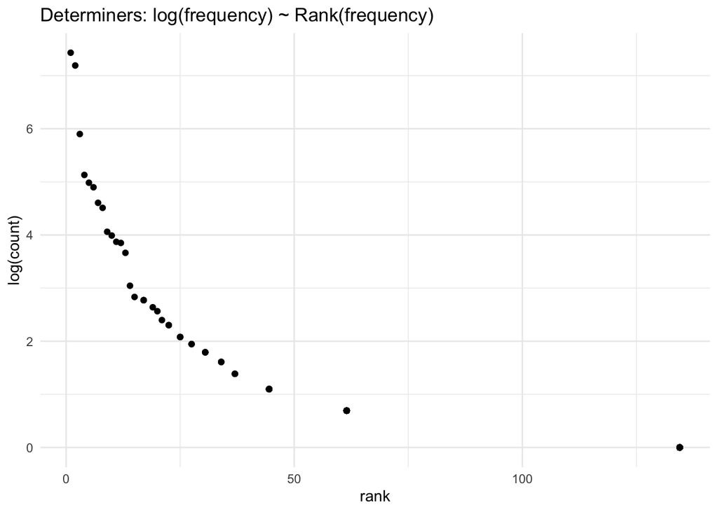

```r
df_determiners$rank = rank(-df_determiners$prop)

df_determiners %>%
  ggplot(aes(x = rank,
             y = log(count))) +
  geom_point() +
  labs(title = "Determiners: log(frequency) ~ Rank(frequency)") +
  theme_minimal()
```

What are the most common head nouns?

```r
df_heads = df_just_nps %>%
  group_by(head_noun) %>%
  summarise(count = n(),
            prop = n() / nrow(df_just_nps))

df_heads$rank = rank(-df_heads$prop)

head(df_heads[order(-df_heads$prop), ], 10)
```

```
## # A tibble: 10 × 4
##    head_noun count   prop  rank
##    <fct>     <int>  <dbl> <dbl>
##  1 lot         200 0.0425   1
##  2 word        188 0.0400   2
##  3 thing       139 0.0296   3
##  4 type        110 0.0234   4
##  5 one          75 0.0160   5.5
##  6 place        75 0.0160   5.5
##  7 person       74 0.0157   7
##  8 people       65 0.0138   8
##  9 body         51 0.0108   9
## 10 animal       49 0.0104  10
```

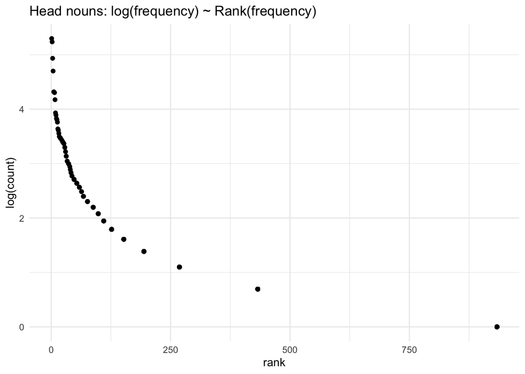

```r
df_heads %>%
  ggplot(aes(x = rank,
             y = log(count))) +
  geom_point() +
  labs(title = "Head nouns: log(frequency) ~ Rank(frequency)") +
  theme_minimal()
```

# Primary analysis 1: Does common ground influence the length of referring expressions?

First, we build a series of nested models. We consider only noun phrases that could conceivably vary in length (i.e., we exclude pronouns).

```r
model_full = glmer(data = df_just_nps,
                   length ~
                     pair_type +
                     trial_with_partner +
                     MINT_Score_Uncued_Correct +
                     Taboo_expertise +
                     Lg10WF +
                     AoA +
                     Conc.M +
                     Dom_Pos +
                    (1 | ppt_id) +
                    (1 | partner_id) +
                    (1 | Order) +
                    (1 | session_id) +
                    (1 | color),
                   family = poisson())
```

```
## boundary (singular) fit: see ?isSingular
```

```r
model_no_pair_type = glmer(data = df_just_nps,
                   length ~
                     # pair_type +
                     trial_with_partner +
                     MINT_Score_Uncued_Correct +
                     Taboo_expertise +
                     Lg10WF +
                     AoA +
                     Conc.M +
                     Dom_Pos +
                    (1 | ppt_id) +
                    (1 | partner_id) +
                    (1 | Order) +
                    (1 | session_id) +
                    (1 | color),
                   family = poisson())
```

```
## boundary (singular) fit: see ?isSingular
```

```r
model_no_twp = glmer(data = df_just_nps,
                   length ~
                     pair_type +
                     # trial_with_partner +
                     MINT_Score_Uncued_Correct +
                     Taboo_expertise +
                     Lg10WF +
                     AoA +
                     Conc.M +
                     Dom_Pos +
                    (1 | ppt_id) +
                    (1 | partner_id) +
                    (1 | Order) +
                    (1 | session_id) +
                    (1 | color),
                   family = poisson())
```

```
## boundary (singular) fit: see ?isSingular
```

```r
anova(model_full, model_no_pair_type)
```

```
## Data: df_just_nps
## Models:
## model_no_pair_type: length ~ trial_with_partner + MINT_Score_Uncued_Correct + Taboo_expertise +
## model_no_pair_type:     Lg10WF + AoA + Conc.M + Dom_Pos + (1 | ppt_id) + (1 | partner_id) +
## model_no_pair_type:     (1 | Order) + (1 | session_id) + (1 | color)
## model_full: length ~ pair_type + trial_with_partner + MINT_Score_Uncued_Correct +
## model_full:     Taboo_expertise + Lg10WF + AoA + Conc.M + Dom_Pos + (1 |
## model_full:     ppt_id) + (1 | partner_id) + (1 | Order) + (1 | session_id) +
## model_full:     (1 | color)
##                    npar   AIC   BIC  logLik deviance  Chisq Df Pr(>Chisq)
## model_no_pair_type   14 13391 13481 -6681.4    13363
## model_full           15 13393 13490 -6681.4    13363 0.0447  1     0.8325
```

```r
anova(model_full, model_no_twp)
```

```
## Data: df_just_nps
## Models:
## model_no_twp: length ~ pair_type + MINT_Score_Uncued_Correct + Taboo_expertise +
## model_no_twp:     Lg10WF + AoA + Conc.M + Dom_Pos + (1 | ppt_id) + (1 | partner_id) +
## model_no_twp:     (1 | Order) + (1 | session_id) + (1 | color)
## model_full: length ~ pair_type + trial_with_partner + MINT_Score_Uncued_Correct +
## model_full:     Taboo_expertise + Lg10WF + AoA + Conc.M + Dom_Pos + (1 |
## model_full:     ppt_id) + (1 | partner_id) + (1 | Order) + (1 | session_id) +
## model_full:     (1 | color)
##              npar   AIC   BIC  logLik deviance  Chisq Df Pr(>Chisq)
## model_no_twp   14 13391 13482 -6681.6    13363
## model_full     15 13393 13490 -6681.4    13363 0.3525  1     0.5527
```

We can also visualize the coefficients from this full model:

```r
summary(model_full)
```

```
## Generalized linear mixed model fit by maximum likelihood (Laplace
##   Approximation) [glmerMod]
##  Family: poisson  ( log )
## Formula: length ~ pair_type + trial_with_partner + MINT_Score_Uncued_Correct +
##     Taboo_expertise + Lg10WF + AoA + Conc.M + Dom_Pos + (1 |
##     ppt_id) + (1 | partner_id) + (1 | Order) + (1 | session_id) +
##     (1 | color)
##    Data: df_just_nps
##
##      AIC      BIC   logLik deviance df.resid
##  13392.8  13489.6  -6681.4  13362.8     4686
##
## Scaled residuals:
##     Min      1Q  Median      3Q     Max
## -0.2400 -0.1939 -0.1763 -0.1453  3.8097
##
## Random effects:
##  Groups     Name        Variance Std.Dev.
##  partner_id (Intercept) 0        0
##  ppt_id     (Intercept) 0        0
##  session_id (Intercept) 0        0
##  color      (Intercept) 0        0
##  Order      (Intercept) 0        0
## Number of obs: 4701, groups:
## partner_id, 68; ppt_id, 65; session_id, 17; color, 4; Order, 2
##
## Fixed effects:
##                             Estimate Std. Error z value Pr(>|z|)
## (Intercept)                0.6500108  0.3632618   1.789   0.0736 .
## pair_typeStranger         -0.0041087  0.0194274  -0.211   0.8325
## trial_with_partner         0.0005774  0.0009723   0.594   0.5526
## MINT_Score_Uncued_Correct  0.0084082  0.0169474   0.496   0.6198
## Taboo_expertise            0.0068551  0.0098126   0.699   0.4848
## Lg10WF                    -0.0051156  0.0158508  -0.323   0.7469
## AoA                       -0.0025611  0.0052061  -0.492   0.6228
## Conc.M                     0.0033538  0.0143132   0.234   0.8147
## Dom_PosNoun               -0.0072602  0.0436399  -0.166   0.8679
## Dom_PosVerb               -0.0248119  0.0482055  -0.515   0.6068
## ---
## Signif. codes:  0 '***' 0.001 '**' 0.01 '*' 0.05 '.' 0.1 ' ' 1
##
## Correlation of Fixed Effects:
##             (Intr) pr_tyS trl_w_ MINT_S Tb_xpr Lg10WF AoA    Conc.M Dm_PsN
## pr_typStrng -0.063
## trl_wth_prt -0.095 -0.007
## MINT_Sc_U_C -0.955  0.048  0.047
## Taboo_xprts  0.148 -0.038 -0.020 -0.216
## Lg10WF      -0.219 -0.015  0.041  0.013 -0.015
## AoA         -0.193  0.000  0.001 -0.011 -0.024  0.480
## Conc.M      -0.220  0.003  0.025  0.034 -0.051  0.252  0.330
## Dom_PosNoun -0.072 -0.035 -0.015  0.025  0.019  0.032 -0.036 -0.370
## Dom_PosVerb -0.109 -0.068 -0.019  0.034 -0.006  0.027  0.068 -0.139  0.775
## convergence code: 0
## boundary (singular) fit: see ?isSingular
```

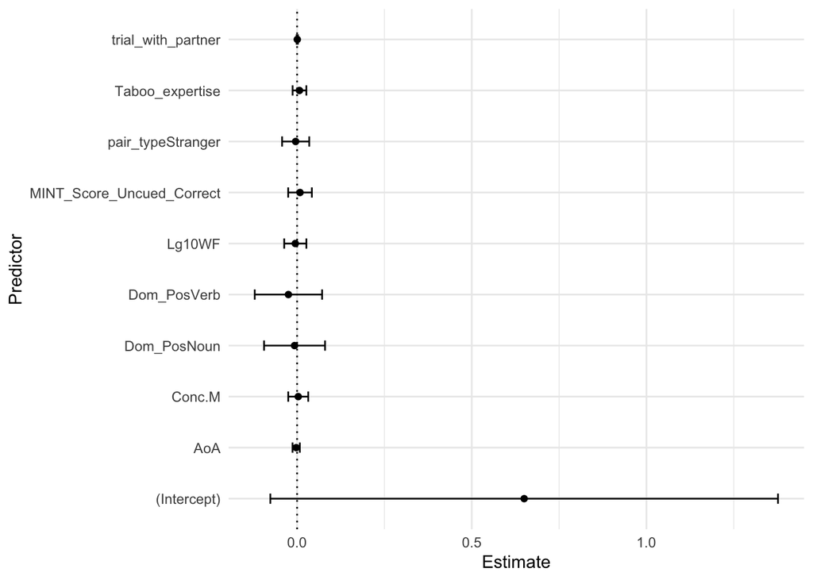

```r
df_tidy = broom.mixed::tidy(model_full)

df_tidy %>%
  filter(effect == "fixed") %>%
  ggplot(aes(x = term,
             y = estimate)) +
  geom_point() +
  coord_flip() +
  geom_hline(yintercept = 0, linetype = "dotted") +
  geom_errorbar(aes(ymin = estimate - 2*std.error,
                    ymax = estimate + 2*std.error),
                width=.2,
                position=position_dodge(.9)) +
  labs(x = "Predictor",
       y = "Estimate") +
  theme_minimal()
```

## Visualizations

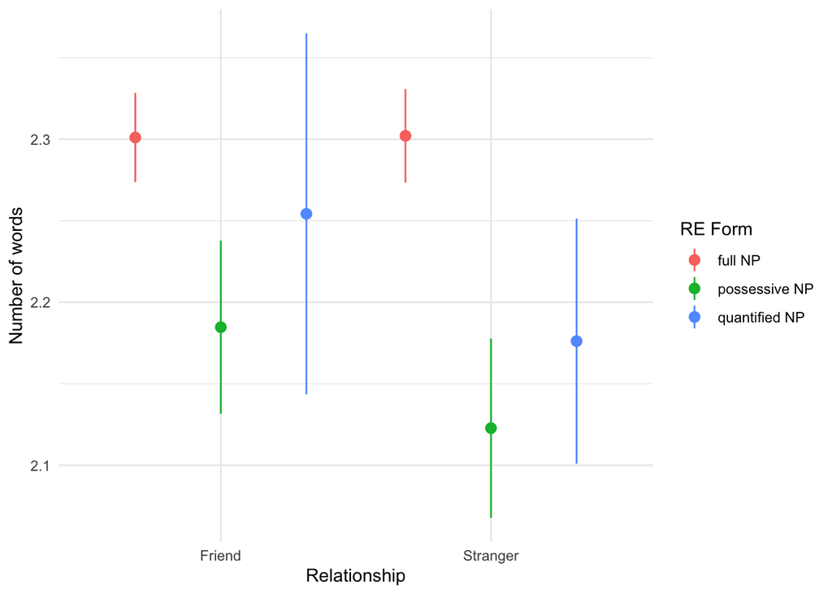

```r
df_just_nps %>%
  ggplot(aes(x = pair_type,
             y = length,
             color = RE_type_granular)) +
  # geom_point(stat = "summary", fun.y = "mean") +
  stat_summary (fun = function(x){mean(x)},
              fun.min = function(x){mean(x) - 2*sd(x)/sqrt(length(x))},
              fun.max = function(x){mean(x) + 2*sd(x)/sqrt(length(x))},
              geom= 'pointrange',
              position=position_dodge(width=0.95)) +
  labs(x = "Relationship",
       y = "Number of words",
       color = "RE Form") +
  theme_minimal()
```

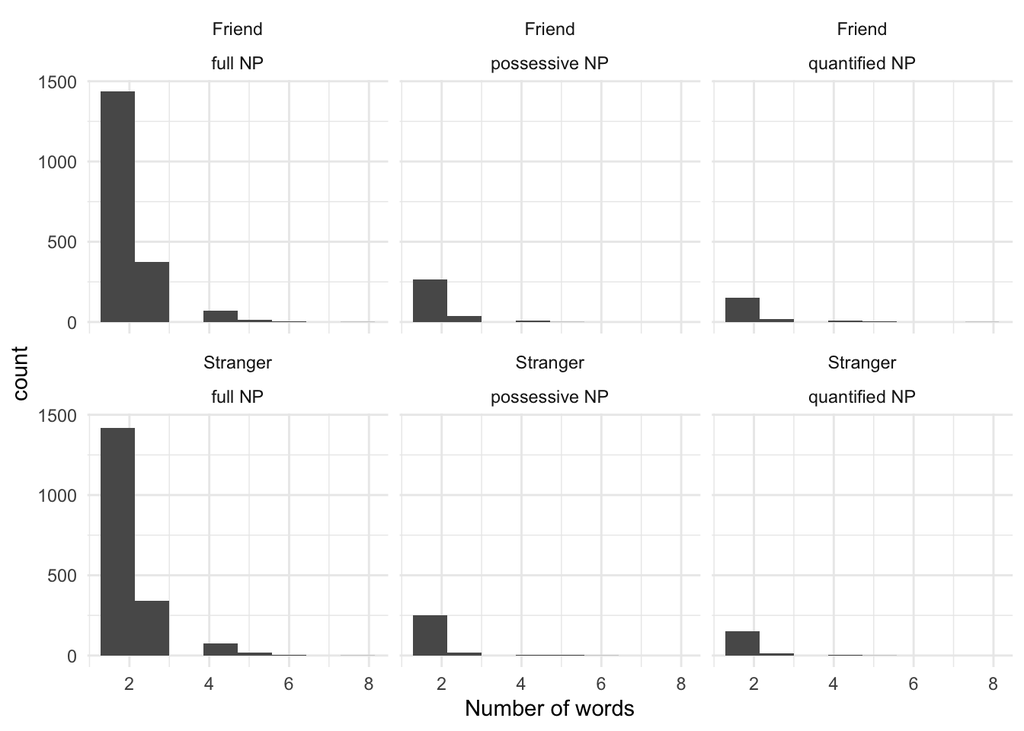

```r
df_just_nps %>%
  ggplot(aes(x = length)) +
  geom_histogram(bins = 8) +
  facet_wrap(~pair_type + RE_type_granular) +
  labs(x = "Number of words") +
  theme_minimal()
```

# Analysis 2: Does common ground influence referential form?

```r
df_restricted_form = df_merged %>%
  filter(RE_type %in% c('full NP', 'PRP 3rd'))
df_restricted_form$RE_type = factor(df_restricted_form$RE_type,
                                    levels = c("full NP", "PRP 3rd"))
nrow(df_restricted_form)
```

```
## [1] 8803
```

```r
model_full = glmer(data = df_restricted_form,
                   RE_type ~
                     pair_type +
                     trial_with_partner +
                     MINT_Score_Uncued_Correct +
                     Taboo_expertise +
                     Lg10WF +
                     AoA +
                     Conc.M +
                     Dom_Pos +
                    (1 | ppt_id) +
                    (1 | partner_id) +
                    (1 | Order) +
                    (1 | session_id) +
                    (1 | color),
                   family = binomial(),
                   control=glmerControl(optimizer="bobyqa"))
```

```
## boundary (singular) fit: see ?isSingular
```

```r
model_no_pair_type = glmer(data = df_restricted_form,
                   RE_type ~
                     # pair_type +
                     trial_with_partner +
                     MINT_Score_Uncued_Correct +
                     Taboo_expertise +
                     Lg10WF +
                     AoA +
                     Conc.M +
                     Dom_Pos +
                    (1 | ppt_id) +
                    (1 | partner_id) +
                    (1 | Order) +
                    (1 | session_id) +
                    (1 | color),
                   family = binomial(),
                   control=glmerControl(optimizer="bobyqa"))
```

```
## boundary (singular) fit: see ?isSingular
```

```r
model_no_twp = glmer(data = df_restricted_form,
                   RE_type ~
                     pair_type +
                     # trial_with_partner +
                     MINT_Score_Uncued_Correct +
                     Taboo_expertise +
                     Lg10WF +
                     AoA +
                     Conc.M +
                     Dom_Pos +
                    (1 | ppt_id) +
                    (1 | partner_id) +
                    (1 | Order) +
                    (1 | session_id) +
                    (1 | color),
                   family = binomial(),
                   control=glmerControl(optimizer="bobyqa"))
```

```
## boundary (singular) fit: see ?isSingular
```

```r
anova(model_full, model_no_pair_type)
```

```
## Data: df_restricted_form
## Models:
## model_no_pair_type: RE_type ~ trial_with_partner + MINT_Score_Uncued_Correct + Taboo_expertise +
## model_no_pair_type:     Lg10WF + AoA + Conc.M + Dom_Pos + (1 | ppt_id) + (1 | partner_id) +
## model_no_pair_type:     (1 | Order) + (1 | session_id) + (1 | color)
## model_full: RE_type ~ pair_type + trial_with_partner + MINT_Score_Uncued_Correct +
## model_full:     Taboo_expertise + Lg10WF + AoA + Conc.M + Dom_Pos + (1 |
## model_full:     ppt_id) + (1 | partner_id) + (1 | Order) + (1 | session_id) +
## model_full:     (1 | color)
##                    npar   AIC   BIC  logLik deviance Chisq Df Pr(>Chisq)
## model_no_pair_type   14 12133 12232 -6052.5    12105
## model_full           15 12132 12238 -6050.9    12102  3.37  1    0.06639 .
## ---
## Signif. codes:  0 '***' 0.001 '**' 0.01 '*' 0.05 '.' 0.1 ' ' 1
```

```r
anova(model_full, model_no_twp)
```

```
## Data: df_restricted_form
## Models:
## model_no_twp: RE_type ~ pair_type + MINT_Score_Uncued_Correct + Taboo_expertise +
## model_no_twp:     Lg10WF + AoA + Conc.M + Dom_Pos + (1 | ppt_id) + (1 | partner_id) +
## model_no_twp:     (1 | Order) + (1 | session_id) + (1 | color)
## model_full: RE_type ~ pair_type + trial_with_partner + MINT_Score_Uncued_Correct +
## model_full:     Taboo_expertise + Lg10WF + AoA + Conc.M + Dom_Pos + (1 |
## model_full:     ppt_id) + (1 | partner_id) + (1 | Order) + (1 | session_id) +
## model_full:     (1 | color)
##              npar   AIC   BIC  logLik deviance Chisq Df Pr(>Chisq)
## model_no_twp   14 12130 12229 -6051.0    12102
## model_full     15 12132 12238 -6050.9    12102 0.198  1     0.6563
```

We can also visualize the coefficients from this full model:

```r
summary(model_full)
```

```
## Generalized linear mixed model fit by maximum likelihood (Laplace
##   Approximation) [glmerMod]
##  Family: binomial  ( logit )
## Formula:
## RE_type ~ pair_type + trial_with_partner + MINT_Score_Uncued_Correct +
##     Taboo_expertise + Lg10WF + AoA + Conc.M + Dom_Pos + (1 |
##     ppt_id) + (1 | partner_id) + (1 | Order) + (1 | session_id) +
##     (1 | color)
##    Data: df_restricted_form
## Control: glmerControl(optimizer = "bobyqa")
##
##      AIC      BIC   logLik deviance df.resid
##  12131.7  12238.0  -6050.9  12101.7     8788
##
## Scaled residuals:
##     Min      1Q  Median      3Q     Max
## -1.2800 -0.9304 -0.7964  1.0498  1.6369
##
## Random effects:
##  Groups     Name        Variance  Std.Dev.
##  partner_id (Intercept) 2.284e-09 4.779e-05
##  ppt_id     (Intercept) 2.732e-02 1.653e-01
##  session_id (Intercept) 1.089e-02 1.044e-01
##  color      (Intercept) 3.789e-10 1.946e-05
##  Order      (Intercept) 0.000e+00 0.000e+00
## Number of obs: 8803, groups:
## partner_id, 68; ppt_id, 65; session_id, 17; color, 4; Order, 2
##
## Fixed effects:
##                             Estimate Std. Error z value Pr(>|z|)
## (Intercept)                0.6518857  1.2027817   0.542  0.58783
## pair_typeStranger          0.0797483  0.0434524   1.835  0.06646 .
## trial_with_partner        -0.0009978  0.0022433  -0.445  0.65646
## MINT_Score_Uncued_Correct -0.0388251  0.0576282  -0.674  0.50049
## Taboo_expertise           -0.0061175  0.0332923  -0.184  0.85421
## Lg10WF                    -0.1033200  0.0363296  -2.844  0.00446 **
## AoA                        0.0005710  0.0116248   0.049  0.96083
## Conc.M                     0.0820143  0.0327638   2.503  0.01231 *
## Dom_PosNoun               -0.1150414  0.0993055  -1.158  0.24668
## Dom_PosVerb               -0.1620245  0.1097967  -1.476  0.14003
## ---
## Signif. codes:  0 '***' 0.001 '**' 0.01 '*' 0.05 '.' 0.1 ' ' 1
##
## Correlation of Fixed Effects:
##             (Intr) pr_tyS trl_w_ MINT_S Tb_xpr Lg10WF AoA    Conc.M Dm_PsN
## pr_typStrng -0.033
## trl_wth_prt -0.072 -0.004
## MINT_Sc_U_C -0.977  0.019  0.039
## Taboo_xprts  0.086 -0.019 -0.022 -0.154
## Lg10WF      -0.149 -0.004  0.037  0.009 -0.011
## AoA         -0.140  0.016 -0.004  0.000 -0.024  0.479
## Conc.M      -0.145  0.000  0.017  0.017 -0.036  0.241  0.324
## Dom_PosNoun -0.058 -0.035 -0.003  0.025  0.017  0.031 -0.014 -0.380
## Dom_PosVerb -0.079 -0.072  0.003  0.025  0.001  0.035  0.092 -0.134  0.771
## convergence code: 0
## boundary (singular) fit: see ?isSingular
```

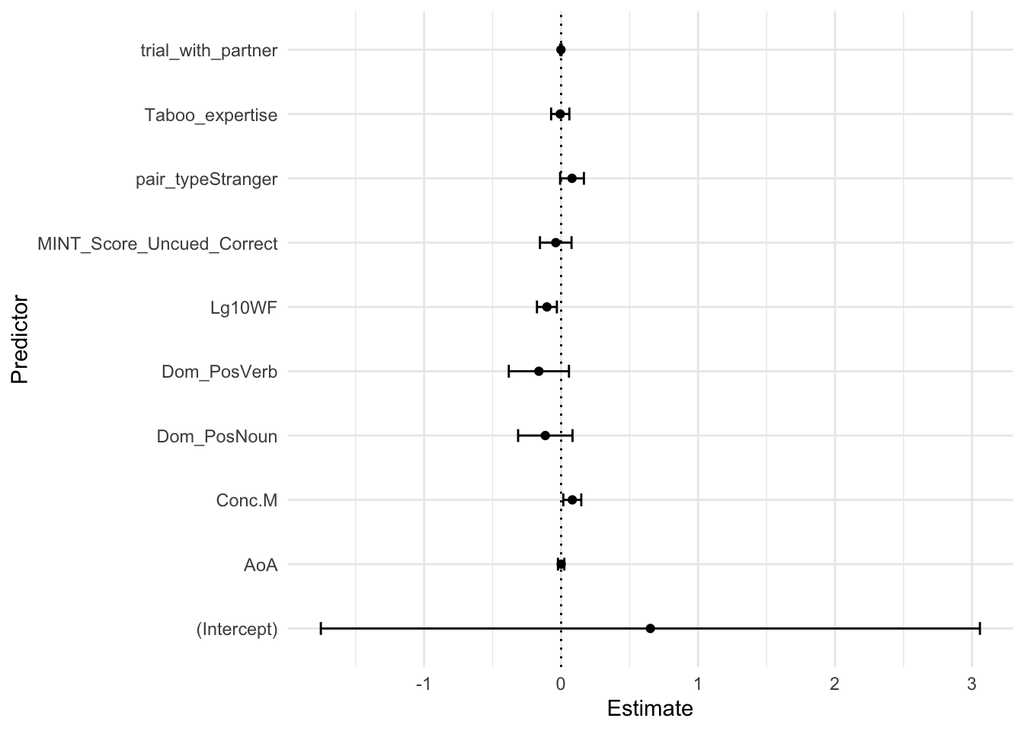

```r
df_tidy = broom.mixed::tidy(model_full)

df_tidy %>%
  filter(effect == "fixed") %>%
  ggplot(aes(x = term,
             y = estimate)) +
  geom_point() +
  coord_flip() +
  geom_hline(yintercept = 0, linetype = "dotted") +
  geom_errorbar(aes(ymin = estimate - 2*std.error,
                    ymax = estimate + 2*std.error),
                width=.2,
                position=position_dodge(.9)) +
  labs(x = "Predictor",
       y = "Estimate") +
  theme_minimal()
```

## Visualizations

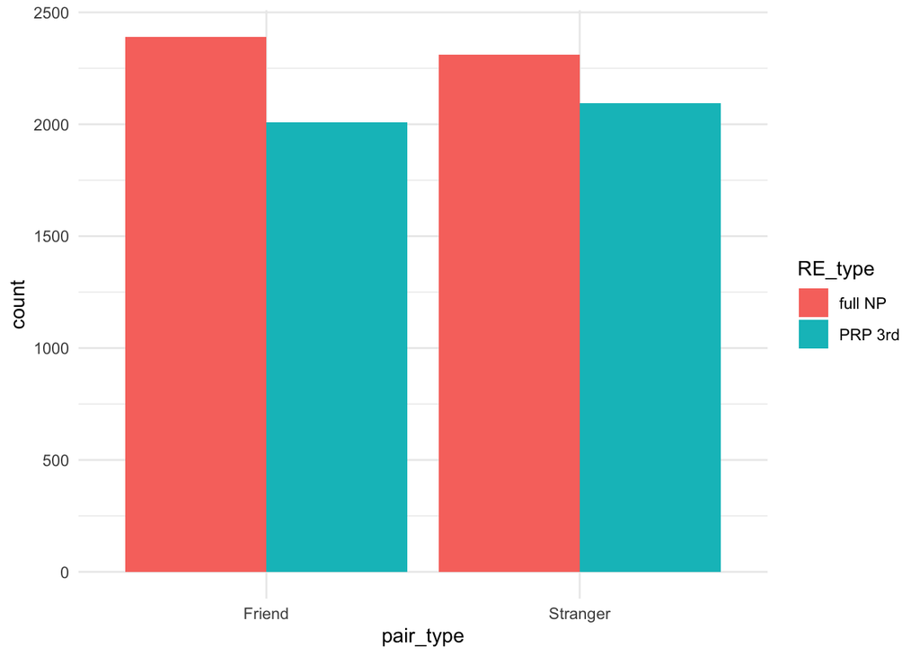

```r
df_restricted_form %>%
  ggplot(aes(x = pair_type,
             fill = RE_type)) +
  geom_bar(stat = "count", position = "dodge") +
  theme_minimal()
```

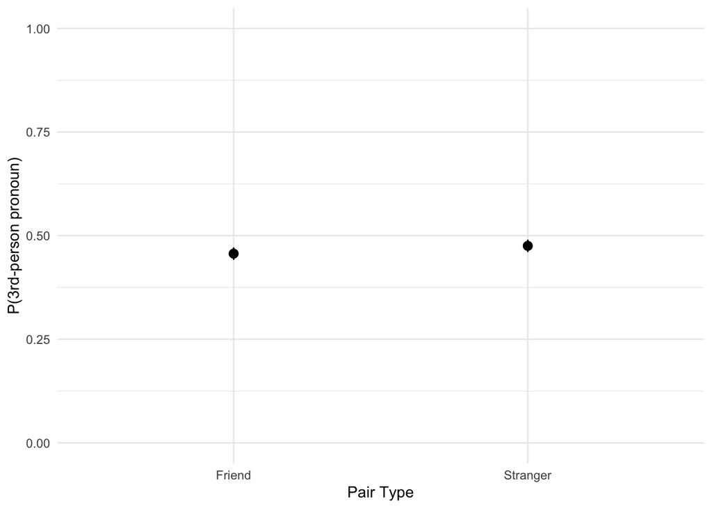

```r
df_restricted_form %>%
  # Set full NP = 0, PRP 3rd = 1
  mutate(re_numeric = as.numeric(RE_type) - 1) %>%
  ggplot(aes(x = pair_type,
             y = re_numeric)) +
  stat_summary (fun = function(x){mean(x)},
              fun.min = function(x){mean(x) - 2*sd(x)/sqrt(length(x))},
              fun.max = function(x){mean(x) + 2*sd(x)/sqrt(length(x))},
              geom= 'pointrange',
              position=position_dodge(width=0.95)) +
  scale_y_continuous(limits = c(0, 1)) +
  labs(x = "Pair Type",
       y = "P(3rd-person pronoun)") +
  theme_minimal()
```

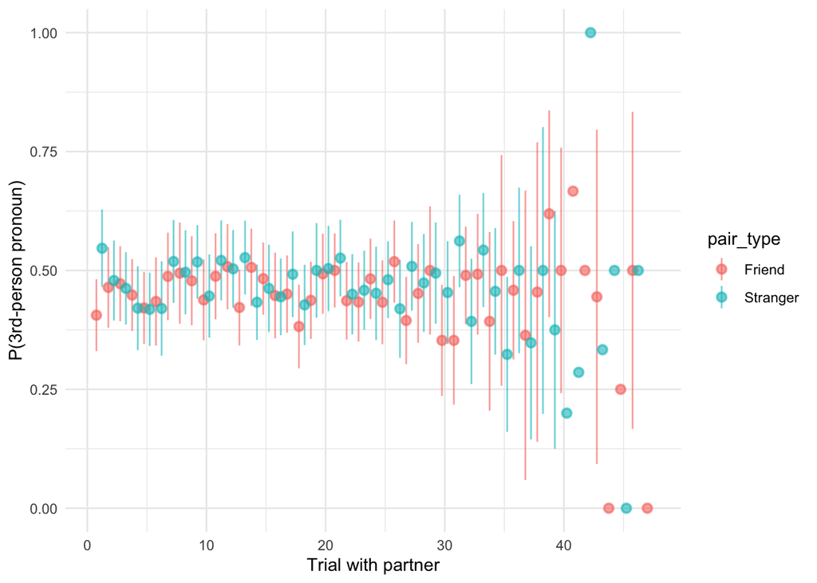

```r
df_restricted_form %>%
  # Set full NP = 0, PRP 3rd = 1
  mutate(re_numeric = as.numeric(RE_type) - 1) %>%
  ggplot(aes(x = trial_with_partner,
             y = re_numeric,
             color = pair_type)) +
  stat_summary (fun = function(x){mean(x)},
              fun.min = function(x){mean(x) - 2*sd(x)/sqrt(length(x))},
              fun.max = function(x){mean(x) + 2*sd(x)/sqrt(length(x))},
              geom= 'pointrange',
              position=position_dodge(width=0.95),
              alpha = .6) +
  labs(x = "Trial with partner",
       y = "P(3rd-person pronoun)") +
  guides(fill=guide_legend(title="Pair Type")) +
  scale_y_continuous(limits = c(0, 1)) +
  theme_minimal()
```

# Analysis 3: Do features of the RE interact with common ground to predict communicative success?

Here, we again limit our analysis to `full NPs` and `3rd-person pronouns`.

```r
df_restricted_form = df_merged %>%
  filter(RE_type %in% c('full NP', 'PRP 3rd'))
df_restricted_form$RE_type = factor(df_restricted_form$RE_type,
                                    levels = c("full NP", "PRP 3rd"))
nrow(df_restricted_form)
```

```
## [1] 8803
```

```r
table(df_restricted_form$RE_type)
```

```
##
## full NP PRP 3rd
##    4701    4102
```

## Win vs. Out of Time

First, we consider the contrast between `Win/Out of time`.

```r
df_win_oot = df_restricted_form %>%
  filter(trial_result != "Lost")
df_win_oot$trial_result = factor(df_win_oot$trial_result, levels = c("Out of time", "Won"))
nrow(df_win_oot)
```

```
## [1] 6903
```

```r
table(df_win_oot$trial_result)
```

```
##
## Out of time         Won
##        2102        4801
```

```r
model_full = glmer(data = df_win_oot,
                   trial_result ~
                     pair_type * RE_type +
                     trial_with_partner * RE_type +
                     pair_type * length +
                     trial_with_partner * length +
                     MINT_Score_Uncued_Correct +
                     Taboo_expertise +
                     Lg10WF +
                     AoA +
                     Conc.M +
                     Dom_Pos +
                    (1 | ppt_id) +
                    (1 | partner_id) +
                    (1 | Order) +
                    (1 | session_id) +
                    (1 | color),
                   family = binomial(),
                   control=glmerControl(optimizer="bobyqa"))
model_r1 = glmer(data = df_win_oot,
                   trial_result ~
                     pair_type + RE_type +
                     trial_with_partner * RE_type +
                     pair_type * length +
                     trial_with_partner * length +
                     MINT_Score_Uncued_Correct +
                     Taboo_expertise +
                     Lg10WF +
                     AoA +
                     Conc.M +
                     Dom_Pos +
                    (1 | ppt_id) +
                    (1 | partner_id) +
                    (1 | Order) +
                    (1 | session_id) +
                    (1 | color),
                   family = binomial(),
                   control=glmerControl(optimizer="bobyqa"))
model_r2 = glmer(data = df_win_oot,
                   trial_result ~
                     pair_type * RE_type +
                     trial_with_partner + RE_type +
                     pair_type * length +
                     trial_with_partner * length +
                     MINT_Score_Uncued_Correct +
                     Taboo_expertise +
                     Lg10WF +
                     AoA +
                     Conc.M +
                     Dom_Pos +
                    (1 | ppt_id) +
                    (1 | partner_id) +
                    (1 | Order) +
                    (1 | session_id) +
                    (1 | color),
                   family = binomial(),
                   control=glmerControl(optimizer="bobyqa"))
model_r3 = glmer(data = df_win_oot,
                   trial_result ~
                     pair_type * RE_type +
                     trial_with_partner * RE_type +
                     pair_type + length +
                     trial_with_partner * length +
                     MINT_Score_Uncued_Correct +
                     Taboo_expertise +
                     Lg10WF +
                     AoA +
                     Conc.M +
                     Dom_Pos +
                    (1 | ppt_id) +
                    (1 | partner_id) +
                    (1 | Order) +
                    (1 | session_id) +
                    (1 | color),
                   family = binomial(),
                   control=glmerControl(optimizer="bobyqa"))
```

```
## boundary (singular) fit: see ?isSingular
```

```r
model_r4 = glmer(data = df_win_oot,
                   trial_result ~
                     pair_type * RE_type +
                     trial_with_partner * RE_type +
                     pair_type * length +
                     trial_with_partner + length +
                     MINT_Score_Uncued_Correct +
                     Taboo_expertise +
                     Lg10WF +
                     AoA +
                     Conc.M +
                     Dom_Pos +
                    (1 | ppt_id) +
                    (1 | partner_id) +
                    (1 | Order) +
                    (1 | session_id) +
                    (1 | color),
                   family = binomial(),
                   control=glmerControl(optimizer="bobyqa"))
anova(model_full, model_r1)
```

```
## Data: df_win_oot
## Models:
## model_r1: trial_result ~ pair_type + RE_type + trial_with_partner * RE_type +
## model_r1:     pair_type * length + trial_with_partner * length + MINT_Score_Uncued_Correct +
## model_r1:     Taboo_expertise + Lg10WF + AoA + Conc.M + Dom_Pos + (1 |
## model_r1:     ppt_id) + (1 | partner_id) + (1 | Order) + (1 | session_id) +
## model_r1:     (1 | color)
## model_full: trial_result ~ pair_type * RE_type + trial_with_partner * RE_type +
## model_full:     pair_type * length + trial_with_partner * length + MINT_Score_Uncued_Correct +
## model_full:     Taboo_expertise + Lg10WF + AoA + Conc.M + Dom_Pos + (1 |
## model_full:     ppt_id) + (1 | partner_id) + (1 | Order) + (1 | session_id) +
## model_full:     (1 | color)
##            npar    AIC    BIC  logLik deviance  Chisq Df Pr(>Chisq)
## model_r1     20 7298.3 7435.1 -3629.2   7258.3
## model_full   21 7300.0 7443.7 -3629.0   7258.0 0.3194  1      0.572
```

```r
anova(model_full, model_r2)
```

```
## Data: df_win_oot
## Models:
## model_r2: trial_result ~ pair_type * RE_type + trial_with_partner + RE_type +
## model_r2:     pair_type * length + trial_with_partner * length + MINT_Score_Uncued_Correct +
## model_r2:     Taboo_expertise + Lg10WF + AoA + Conc.M + Dom_Pos + (1 |
## model_r2:     ppt_id) + (1 | partner_id) + (1 | Order) + (1 | session_id) +
## model_r2:     (1 | color)
## model_full: trial_result ~ pair_type * RE_type + trial_with_partner * RE_type +
## model_full:     pair_type * length + trial_with_partner * length + MINT_Score_Uncued_Correct +
## model_full:     Taboo_expertise + Lg10WF + AoA + Conc.M + Dom_Pos + (1 |
## model_full:     ppt_id) + (1 | partner_id) + (1 | Order) + (1 | session_id) +
## model_full:     (1 | color)
##            npar    AIC    BIC  logLik deviance  Chisq Df Pr(>Chisq)
## model_r2     20 7298.8 7435.6 -3629.4   7258.8
## model_full   21 7300.0 7443.7 -3629.0   7258.0 0.8194  1     0.3654
```

```r
anova(model_full, model_r3)
```

```
## Data: df_win_oot
## Models:
## model_r3: trial_result ~ pair_type * RE_type + trial_with_partner * RE_type +
## model_r3:     pair_type + length + trial_with_partner * length + MINT_Score_Uncued_Correct +
## model_r3:     Taboo_expertise + Lg10WF + AoA + Conc.M + Dom_Pos + (1 |
## model_r3:     ppt_id) + (1 | partner_id) + (1 | Order) + (1 | session_id) +
## model_r3:     (1 | color)
## model_full: trial_result ~ pair_type * RE_type + trial_with_partner * RE_type +
## model_full:     pair_type * length + trial_with_partner * length + MINT_Score_Uncued_Correct +
## model_full:     Taboo_expertise + Lg10WF + AoA + Conc.M + Dom_Pos + (1 |
## model_full:     ppt_id) + (1 | partner_id) + (1 | Order) + (1 | session_id) +
## model_full:     (1 | color)
##            npar    AIC    BIC  logLik deviance  Chisq Df Pr(>Chisq)
## model_r3     20 7300.2 7437.0 -3630.1   7260.2
## model_full   21 7300.0 7443.7 -3629.0   7258.0 2.1357  1     0.1439
```

```r
anova(model_full, model_r4)
```

```
## Data: df_win_oot
## Models:
## model_r4: trial_result ~ pair_type * RE_type + trial_with_partner * RE_type +
## model_r4:     pair_type * length + trial_with_partner + length + MINT_Score_Uncued_Correct +
## model_r4:     Taboo_expertise + Lg10WF + AoA + Conc.M + Dom_Pos + (1 |
## model_r4:     ppt_id) + (1 | partner_id) + (1 | Order) + (1 | session_id) +
## model_r4:     (1 | color)
## model_full: trial_result ~ pair_type * RE_type + trial_with_partner * RE_type +
## model_full:     pair_type * length + trial_with_partner * length + MINT_Score_Uncued_Correct +
## model_full:     Taboo_expertise + Lg10WF + AoA + Conc.M + Dom_Pos + (1 |
## model_full:     ppt_id) + (1 | partner_id) + (1 | Order) + (1 | session_id) +
## model_full:     (1 | color)
##            npar    AIC    BIC  logLik deviance Chisq Df Pr(>Chisq)
## model_r4     20 7298.1 7434.9 -3629.1   7258.1
## model_full   21 7300.0 7443.7 -3629.0   7258.0   0.1  1     0.7518
```

We can also visualize the coefficients from this full model:

```r
summary(model_full)
```

```
## Generalized linear mixed model fit by maximum likelihood (Laplace
##   Approximation) [glmerMod]
##  Family: binomial  ( logit )
## Formula: trial_result ~ pair_type * RE_type + trial_with_partner * RE_type +
##     pair_type * length + trial_with_partner * length + MINT_Score_Uncued_Correct +
##     Taboo_expertise + Lg10WF + AoA + Conc.M + Dom_Pos + (1 |
##     ppt_id) + (1 | partner_id) + (1 | Order) + (1 | session_id) +
##     (1 | color)
##    Data: df_win_oot
## Control: glmerControl(optimizer = "bobyqa")
##
##      AIC      BIC   logLik deviance df.resid
##   7300.0   7443.7  -3629.0   7258.0     6882
##
## Scaled residuals:
##     Min      1Q  Median      3Q     Max
## -4.6070 -0.7563  0.3610  0.6464  2.3292
##
## Random effects:
##  Groups     Name        Variance  Std.Dev.
##  partner_id (Intercept) 6.524e-01 0.8077065
##  ppt_id     (Intercept) 6.981e-01 0.8355219
##  session_id (Intercept) 3.913e-01 0.6255349
##  color      (Intercept) 1.668e-03 0.0408360
##  Order      (Intercept) 7.725e-07 0.0008789
## Number of obs: 6903, groups:
## partner_id, 68; ppt_id, 65; session_id, 17; color, 4; Order, 2
##
## Fixed effects:
##                                    Estimate Std. Error z value Pr(>|z|)
## (Intercept)                       -0.473100   5.384936  -0.088   0.9300
## pair_typeStranger                 -0.244725   0.325779  -0.751   0.4525
## RE_typePRP 3rd                    -0.328428   0.229211  -1.433   0.1519
## trial_with_partner                 0.014023   0.017619   0.796   0.4261
## length                            -0.241371   0.149972  -1.609   0.1075
## MINT_Score_Uncued_Correct          0.022832   0.262161   0.087   0.9306
## Taboo_expertise                   -0.083348   0.132556  -0.629   0.5295
## Lg10WF                             0.441549   0.051321   8.604  < 2e-16 ***
## AoA                               -0.130091   0.015864  -8.201 2.39e-16 ***
## Conc.M                             0.388807   0.046645   8.335  < 2e-16 ***
## Dom_PosNoun                       -0.314285   0.135652  -2.317   0.0205 *
## Dom_PosVerb                        0.129097   0.152719   0.845   0.3979
## pair_typeStranger:RE_typePRP 3rd   0.118661   0.211776   0.560   0.5753
## RE_typePRP 3rd:trial_with_partner -0.010560   0.011458  -0.922   0.3567
## pair_typeStranger:length           0.200824   0.137854   1.457   0.1452
## trial_with_partner:length         -0.002460   0.007484  -0.329   0.7424
## ---
## Signif. codes:  0 '***' 0.001 '**' 0.01 '*' 0.05 '.' 0.1 ' ' 1
```

```
##
## Correlation matrix not shown by default, as p = 16 > 12.
## Use print(x, correlation=TRUE)  or
##     vcov(x)        if you need it
```

```
## convergence code: 0
## Model failed to converge with max|grad| = 0.0245254 (tol = 0.002, component 1)
## Model is nearly unidentifiable: very large eigenvalue
##  - Rescale variables?
## Model is nearly unidentifiable: large eigenvalue ratio
##  - Rescale variables?
```

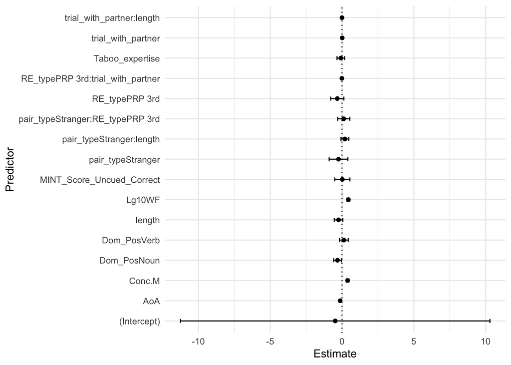

```r
df_tidy = broom.mixed::tidy(model_full)

df_tidy %>%
  filter(effect == "fixed") %>%
  ggplot(aes(x = term,
             y = estimate)) +
  geom_point() +
  coord_flip() +
  geom_hline(yintercept = 0, linetype = "dotted") +
  geom_errorbar(aes(ymin = estimate - 2*std.error,
                    ymax = estimate + 2*std.error),
                width=.2,
                position=position_dodge(.9)) +
  labs(x = "Predictor",
       y = "Estimate") +
  theme_minimal()
```

## Visualizations

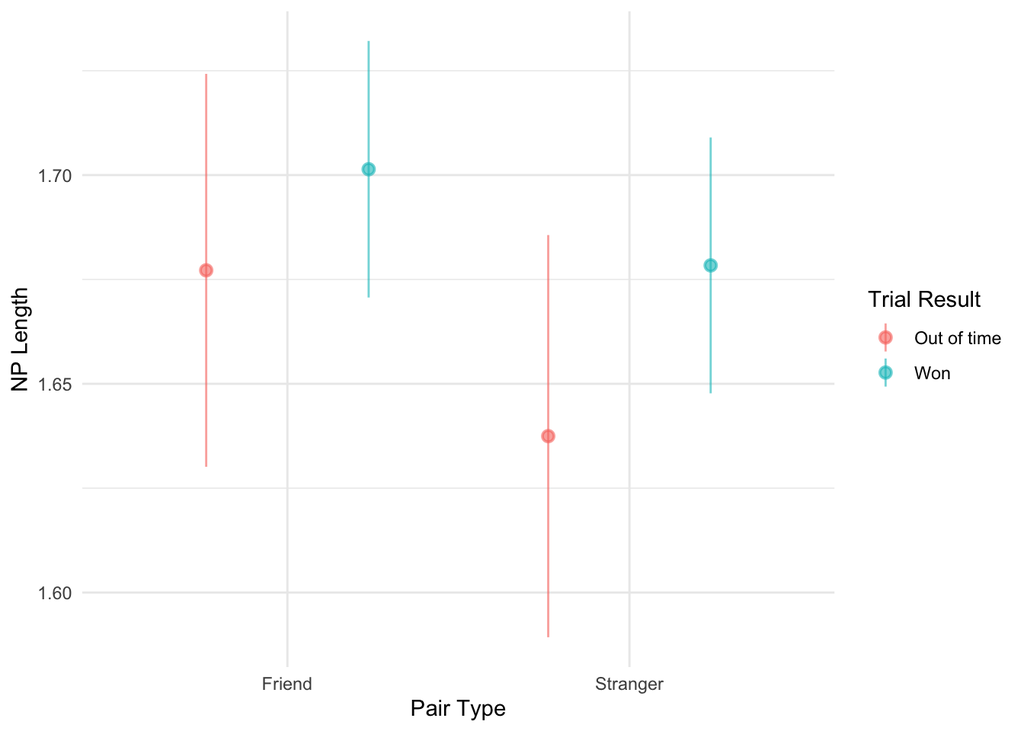

```r
df_win_oot = df_win_oot %>%
  mutate(
    outcome_numeric = case_when(
      trial_result == "Won" ~ 1,
      trial_result == "Out of time" ~ 0
    )
  )

df_win_oot %>%
  ggplot(aes(x = pair_type,
             y = length,
             color = trial_result)) +
  stat_summary (fun = function(x){mean(x)},
              fun.min = function(x){mean(x) - 2*sd(x)/sqrt(length(x))},
              fun.max = function(x){mean(x) + 2*sd(x)/sqrt(length(x))},
              geom= 'pointrange',
              position=position_dodge(width=0.95),
              alpha = .6) +
  labs(x = "Pair Type",
       y = "NP Length") +
  guides(color=guide_legend(title="Trial Result")) +
  theme_minimal()
```

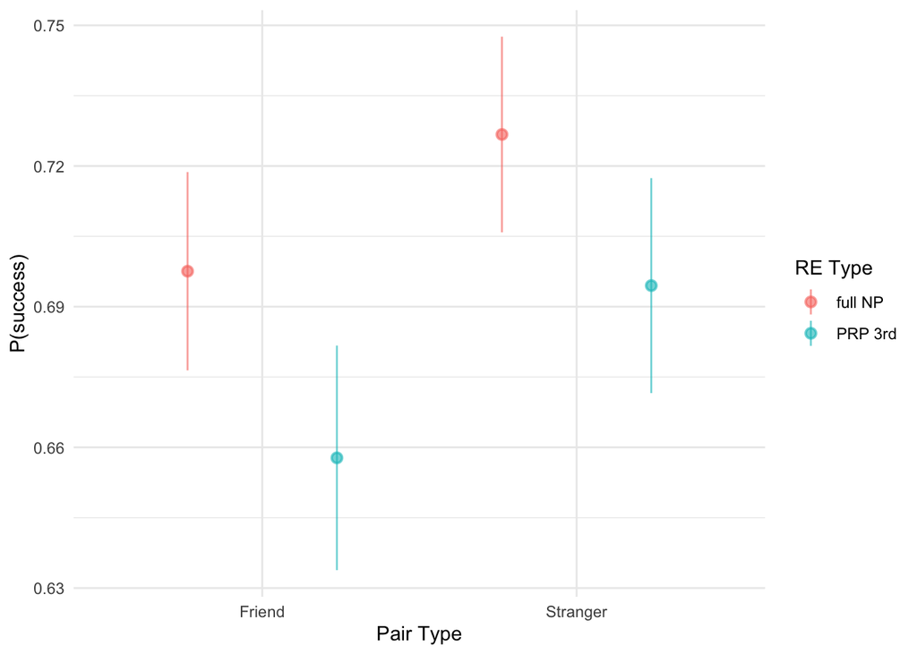

```r
df_win_oot %>%
  ggplot(aes(x = pair_type,
             y = outcome_numeric,
             color = RE_type)) +
  stat_summary (fun = function(x){mean(x)},
              fun.min = function(x){mean(x) - 2*sd(x)/sqrt(length(x))},
              fun.max = function(x){mean(x) + 2*sd(x)/sqrt(length(x))},
              geom= 'pointrange',
              position=position_dodge(width=0.95),
              alpha = .6) +
  labs(x = "Pair Type",
       y = "P(success)") +
  guides(color=guide_legend(title="RE Type")) +
  theme_minimal()
```

```r
df_win_lose = df_restricted_form %>%
  filter(trial_result != "Out of time")
df_win_lose$trial_result = factor(df_win_lose$trial_result, levels = c("Lost", "Won"))
nrow(df_win_lose)
```

```
## [1] 6701
```

```r
table(df_win_lose$trial_result)
```

```
##
## Lost  Won
## 1900 4801
```

```r
model_full = glmer(data = df_win_lose,
                   trial_result ~
                     pair_type * RE_type +
                     trial_with_partner * RE_type +
                     pair_type * length +
                     trial_with_partner * length +
                     MINT_Score_Uncued_Correct +
                     Taboo_expertise +
                     Lg10WF +
                     AoA +
                     Conc.M +
                     Dom_Pos +
                    (1 | ppt_id) +
                    (1 | partner_id) +
                    (1 | Order) +
                    (1 | session_id) +
                    (1 | color),
                   family = binomial(),
                   control=glmerControl(optimizer="bobyqa"))
```

```
## boundary (singular) fit: see ?isSingular
```

```r
model_r1 = glmer(data = df_win_lose,
                   trial_result ~
                     pair_type + RE_type +
                     trial_with_partner * RE_type +
                     pair_type * length +
                     trial_with_partner * length +
                     MINT_Score_Uncued_Correct +
                     Taboo_expertise +
                     Lg10WF +
                     AoA +
                     Conc.M +
                     Dom_Pos +
                    (1 | ppt_id) +
                    (1 | partner_id) +
                    (1 | Order) +
                    (1 | session_id) +
                    (1 | color),
                   family = binomial(),
                   control=glmerControl(optimizer="bobyqa"))
```

```
## boundary (singular) fit: see ?isSingular
```

```r
model_r2 = glmer(data = df_win_lose,
                   trial_result ~
                     pair_type * RE_type +
                     trial_with_partner + RE_type +
                     pair_type * length +
                     trial_with_partner * length +
                     MINT_Score_Uncued_Correct +
                     Taboo_expertise +
                     Lg10WF +
                     AoA +
                     Conc.M +
                     Dom_Pos +
                    (1 | ppt_id) +
                    (1 | partner_id) +
                    (1 | Order) +
                    (1 | session_id) +
                    (1 | color),
                   family = binomial(),
                   control=glmerControl(optimizer="bobyqa"))
```

```
## boundary (singular) fit: see ?isSingular
```

```r
model_r3 = glmer(data = df_win_lose,
                   trial_result ~
                     pair_type * RE_type +
                     trial_with_partner * RE_type +
                     pair_type + length +
                     trial_with_partner * length +
                     MINT_Score_Uncued_Correct +
                     Taboo_expertise +
                     Lg10WF +
                     AoA +
                     Conc.M +
                     Dom_Pos +
                    (1 | ppt_id) +
                    (1 | partner_id) +
                    (1 | Order) +
                    (1 | session_id) +
                    (1 | color),
                   family = binomial(),
                   control=glmerControl(optimizer="bobyqa"))
```

```
## boundary (singular) fit: see ?isSingular
```

```r
model_r4 = glmer(data = df_win_lose,
                   trial_result ~
                     pair_type * RE_type +
                     trial_with_partner * RE_type +
                     pair_type * length +
                     trial_with_partner + length +
                     MINT_Score_Uncued_Correct +
                     Taboo_expertise +
                     Lg10WF +
                     AoA +
                     Conc.M +
                     Dom_Pos +
                    (1 | ppt_id) +
                    (1 | partner_id) +
                    (1 | Order) +
                    (1 | session_id) +
                    (1 | color),
                   family = binomial(),
                   control=glmerControl(optimizer="bobyqa"))
```

```
## boundary (singular) fit: see ?isSingular
```

```r
anova(model_full, model_r1)
```

```
## Data: df_win_lose
## Models:
## model_r1: trial_result ~ pair_type + RE_type + trial_with_partner * RE_type +
## model_r1:     pair_type * length + trial_with_partner * length + MINT_Score_Uncued_Correct +
## model_r1:     Taboo_expertise + Lg10WF + AoA + Conc.M + Dom_Pos + (1 |
## model_r1:     ppt_id) + (1 | partner_id) + (1 | Order) + (1 | session_id) +
## model_r1:     (1 | color)
## model_full: trial_result ~ pair_type * RE_type + trial_with_partner * RE_type +
## model_full:     pair_type * length + trial_with_partner * length + MINT_Score_Uncued_Correct +
## model_full:     Taboo_expertise + Lg10WF + AoA + Conc.M + Dom_Pos + (1 |
## model_full:     ppt_id) + (1 | partner_id) + (1 | Order) + (1 | session_id) +
## model_full:     (1 | color)
##            npar    AIC    BIC  logLik deviance Chisq Df Pr(>Chisq)
## model_r1     20 7169.3 7305.5 -3564.6   7129.3
## model_full   21 7171.3 7314.3 -3564.6   7129.3 0.002  1     0.9647
```

```r
anova(model_full, model_r2)
```

```
## Data: df_win_lose
## Models:
## model_r2: trial_result ~ pair_type * RE_type + trial_with_partner + RE_type +
## model_r2:     pair_type * length + trial_with_partner * length + MINT_Score_Uncued_Correct +
## model_r2:     Taboo_expertise + Lg10WF + AoA + Conc.M + Dom_Pos + (1 |
## model_r2:     ppt_id) + (1 | partner_id) + (1 | Order) + (1 | session_id) +
## model_r2:     (1 | color)
## model_full: trial_result ~ pair_type * RE_type + trial_with_partner * RE_type +
## model_full:     pair_type * length + trial_with_partner * length + MINT_Score_Uncued_Correct +
## model_full:     Taboo_expertise + Lg10WF + AoA + Conc.M + Dom_Pos + (1 |
## model_full:     ppt_id) + (1 | partner_id) + (1 | Order) + (1 | session_id) +
## model_full:     (1 | color)
##            npar    AIC    BIC  logLik deviance  Chisq Df Pr(>Chisq)
## model_r2     20 7171.1 7307.3 -3565.6   7131.1
## model_full   21 7171.3 7314.3 -3564.6   7129.3 1.8516  1     0.1736
```

```r
anova(model_full, model_r3)
```

```
## Data: df_win_lose
## Models:
## model_r3: trial_result ~ pair_type * RE_type + trial_with_partner * RE_type +
## model_r3:     pair_type + length + trial_with_partner * length + MINT_Score_Uncued_Correct +
## model_r3:     Taboo_expertise + Lg10WF + AoA + Conc.M + Dom_Pos + (1 |
## model_r3:     ppt_id) + (1 | partner_id) + (1 | Order) + (1 | session_id) +
## model_r3:     (1 | color)
## model_full: trial_result ~ pair_type * RE_type + trial_with_partner * RE_type +
## model_full:     pair_type * length + trial_with_partner * length + MINT_Score_Uncued_Correct +
## model_full:     Taboo_expertise + Lg10WF + AoA + Conc.M + Dom_Pos + (1 |
## model_full:     ppt_id) + (1 | partner_id) + (1 | Order) + (1 | session_id) +
## model_full:     (1 | color)
##            npar    AIC    BIC  logLik deviance  Chisq Df Pr(>Chisq)
## model_r3     20 7169.3 7305.5 -3564.6   7129.3
## model_full   21 7171.3 7314.3 -3564.6   7129.3 0.0195  1     0.8889
```

```r
anova(model_full, model_r4)
```

```
## Data: df_win_lose
## Models:
## model_r4: trial_result ~ pair_type * RE_type + trial_with_partner * RE_type +
## model_r4:     pair_type * length + trial_with_partner + length + MINT_Score_Uncued_Correct +
## model_r4:     Taboo_expertise + Lg10WF + AoA + Conc.M + Dom_Pos + (1 |
## model_r4:     ppt_id) + (1 | partner_id) + (1 | Order) + (1 | session_id) +
## model_r4:     (1 | color)
## model_full: trial_result ~ pair_type * RE_type + trial_with_partner * RE_type +
## model_full:     pair_type * length + trial_with_partner * length + MINT_Score_Uncued_Correct +
## model_full:     Taboo_expertise + Lg10WF + AoA + Conc.M + Dom_Pos + (1 |
## model_full:     ppt_id) + (1 | partner_id) + (1 | Order) + (1 | session_id) +
## model_full:     (1 | color)
##            npar    AIC    BIC  logLik deviance  Chisq Df Pr(>Chisq)
## model_r4     20 7171.5 7307.7 -3565.7   7131.5
## model_full   21 7171.3 7314.3 -3564.6   7129.3 2.2242  1     0.1359
```

We can also visualize the coefficients from this full model:

```r
summary(model_full)
```

[output not shown]

```
##
## Correlation matrix not shown by default, as p = 16 > 12.
## Use print(x, correlation=TRUE)  or
##     vcov(x)        if you need it
```

```
## convergence code: 1
## boundary (singular) fit: see ?isSingular
```

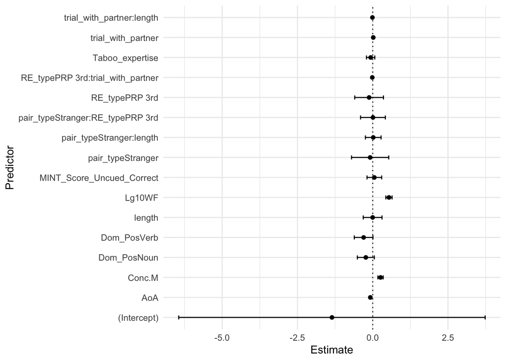

```r
df_tidy = broom.mixed::tidy(model_full)

df_tidy %>%
  filter(effect == "fixed") %>%
  ggplot(aes(x = term,
             y = estimate)) +
  geom_point() +
  coord_flip() +
  geom_hline(yintercept = 0, linetype = "dotted") +
  geom_errorbar(aes(ymin = estimate - 2*std.error,
                    ymax = estimate + 2*std.error),
                width=.2,
                position=position_dodge(.9)) +
  labs(x = "Predictor",
       y = "Estimate") +
  theme_minimal()
```

## Visualizations

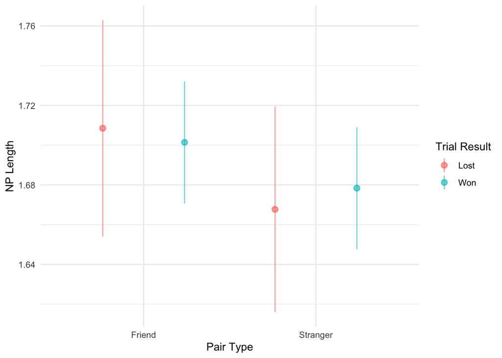

```r
df_win_lose = df_win_lose %>%
  mutate(
    outcome_numeric = case_when(
      trial_result == "Won" ~ 1,
      trial_result == "Lost" ~ 0
    )
  )

df_win_lose %>%
  ggplot(aes(x = pair_type,
             y = length,
             color = trial_result)) +
  stat_summary (fun = function(x){mean(x)},
              fun.min = function(x){mean(x) - 2*sd(x)/sqrt(length(x))},
              fun.max = function(x){mean(x) + 2*sd(x)/sqrt(length(x))},
              geom= 'pointrange',
              position=position_dodge(width=0.95),
              alpha = .6) +
  labs(x = "Pair Type",
       y = "NP Length") +
  guides(color=guide_legend(title="Trial Result")) +
  theme_minimal()
```

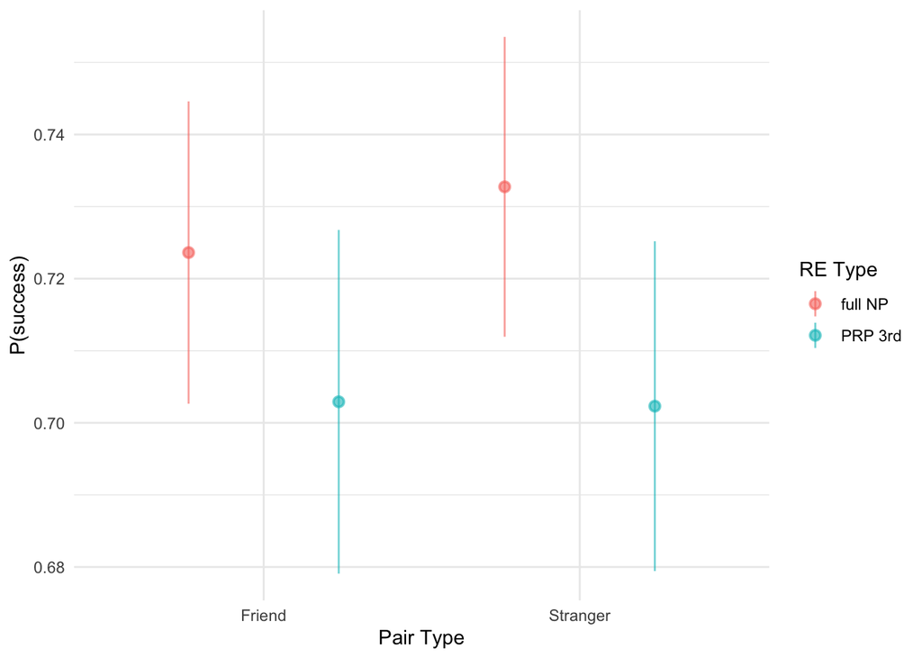

```r
df_win_lose %>%
  ggplot(aes(x = pair_type,
             y = outcome_numeric,
             color = RE_type)) +
  stat_summary (fun = function(x){mean(x)},
              fun.min = function(x){mean(x) - 2*sd(x)/sqrt(length(x))},
              fun.max = function(x){mean(x) + 2*sd(x)/sqrt(length(x))},
              geom= 'pointrange',
              position=position_dodge(width=0.95),
              alpha = .6) +
  labs(x = "Pair Type",
       y = "P(success)") +
  guides(color=guide_legend(title="RE Type")) +
  theme_minimal()
```